# Exercise 11

Author

Gianfranco Botta (GianfrancoBotta)

Published

December 5, 2023

## Set seed

```r
set.seed(42)
```

## Import libraries

```r
library(ExperimentHub)
library(CATALYST)
library(diffcyt)
library(readxl)
library(ggplot2)
```

## Question 1

*Loading the data*

0. Load the ExperimentHub package.
1. Initialize a Hub instance eh with the ExperimentHub() function.

```r
eh <- ExperimentHub()
```

2. Use query() to retrieve any records that match the keyword “Bodenmiller”.

```r
apData <- query(eh, "Bodenmiller")
apData
```

```
ExperimentHub with 21 records
# snapshotDate(): 2023-10-24
# $dataprovider: NA, Bodenmiller Group
# $species: Homo sapiens
# $rdataclass: flowSet, SummarizedExperiment, data.frame
# additional mcols(): taxonomyid, genome, description,
#   coordinate_1_based, maintainer, rdatadateadded, preparerclass, tags,
#   rdatapath, sourceurl, sourcetype
# retrieve records with, e.g., 'object[["EH2254"]]'

           title
  EH2254 | Bodenmiller_BCR_XL_SE
  EH2255 | Bodenmiller_BCR_XL_flowSet
  EH3047 | Weber_BCR_XL_sim_main_SE
  EH3048 | Weber_BCR_XL_sim_main_flowSet
  EH3049 | Weber_BCR_XL_sim_null_rep1_SE
  ...      ...
  EH3061 | Weber_BCR_XL_sim_less_distinct_less_50pc_SE
  EH3062 | Weber_BCR_XL_sim_less_distinct_less_50pc_flowSet
  EH3063 | Weber_BCR_XL_sim_less_distinct_less_75pc_SE
  EH3064 | Weber_BCR_XL_sim_less_distinct_less_75pc_flowSet
  EH3564 | Damond Diabetes Spatial Dataset
```

3. Load the “Bodenmiller_BCR_XL_flowSet” into R using eh[[]].

```r
eh <- eh[["EH2255"]]
```

4. Briefly explore the flowSet object. How many markers are recorded? How many samples are there? How many cells per sample?

```r
for (i in 1:16){
  print(dim(eh[[i]]))
}
```

```
    events parameters
      2838         39
    events parameters
      2739         39
    events parameters
     16675         39
    events parameters
     16725         39
    events parameters
     12252         39
    events parameters
      9434         39
    events parameters
      8990         39
    events parameters
      6906         39
    events parameters
      8543         39
    events parameters
     11962         39
    events parameters
      8622         39
    events parameters
     11038         39
    events parameters
     14770         39
    events parameters
     15974         39
    events parameters
     11653         39
    events parameters
     13670         39
```

```r
length(eh)
```

```
[1] 16
```

The flowSet object comprises 33 recorded markers in 16 samples (in the 39 it includes: “Time”, “Cell_length”, “group_id”, “patient_id”, “sample_id” and “population_id”), but the 16 samples come from 8 patients. The number of cells per sample is variable, as printed from the previous chunk.

## Question 2

*Constructing a SingleCellExperiment*

0. Execute the code below to load the panel and metadata tables.

```r
# download panel & metadata
url <- "https://zenodo.org/records/10039274/files"
fns <- list(panel = "PBMC8_panel_v3.xlsx", md = "PBMC8_metadata.xlsx")
for (fn in fns) download.file(file.path(url, fn), destfile = fn, mode = "wb")

# load into R
panel <- read_excel(fns$panel)
md <- read_excel(fns$md)
```

1. Give a brief description of each column of the panel and metadata tables.

PANEL DESCRIPTION: 1) fcs_colname stands for “Flow Cytometry Standard.” The FCS file provides a detailed description of: instrument used to obtain the data, sample measured, data obtained, the results of analysis of the data; 2) antibody is the antibody used for the cytometry experiment; 3) marker_class indicates whether the marker is used to mark cell type or cell state.

METADATA DESCRIPTION: 1) file_name is the name of the file related to that row; 2) sample_id and patient_id indicate the id of samples and patients involved in the experiment; 3) condition indicates whether the sample is under Ref or BCRXL condition.

0. Load the CATALYST package.
1. Use prepData() to construct a SCE from the flowSet, panel and metadata loaded above.

```r
(sce <- prepData(eh, panel, md))
```

```
class: SingleCellExperiment
dim: 24 172791
metadata(2): experiment_info chs_by_fcs
assays(2): counts exprs
rownames(24): CD3 CD45 ... HLA-DR CD7
rowData names(3): channel_name marker_name marker_class
colnames: NULL
colData names(3): sample_id condition patient_id
reducedDimNames(0):
mainExpName: NULL
altExpNames(0):
```

2. How many markers and how many cells are there?

```r
n_cells <- sum(sce@metadata$experiment_info$n_cells)
```

There are 172791 cells in total.

```r
n_markers <- length(sce@metadata$chs_by_fcs) / 16
```

The markers that there are in each cells are: 24. Compared to marker_info, there are some values missing: “BC1(La139)Dd” “BC2(Pr141)Dd” “BC3(Nd146)Dd” “BC4(Tb159)Dd” “BC5(Ho165)Dd” “BC6(Tm169)Dd” “BC7(Lu175)Dd” “DNA-1(Ir191)Dd” “DNA-2(Ir193)Dd”

## Question 3

*Type and state markers*

1. Print the set of type markers pre-defined in the SCE.

```r
type_markers(sce)
```

```
 [1] "CD3"    "CD45"   "CD4"    "CD20"   "CD33"   "CD123"  "CD14"   "IgM"
 [9] "HLA-DR" "CD7"
```

2. Using plotExprHeatmap, plot a heatmap of median marker expression across samples.

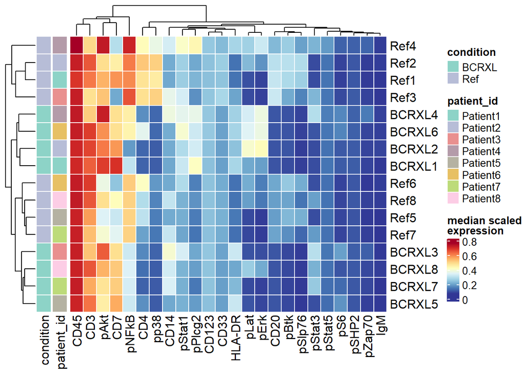

```r
plotExprHeatmap(sce, fun = "median")
```

3. Are there type markers that may violate the above assumption?

CD4, CD7 and CD20 can clearly break the assumptions of type markers expressions being fairly consistent across experimental states (stimulated vs unstimulated).

## Question 4

*Clustering*

1. Cluster the data into 8x8 high-resolution-, and 2-10 metaclusters.

```r
sce <- cluster(sce, features = "type",
               xdim = 8, ydim = 8,
               maxK = 10, seed = 1)
colData(sce)
```

```
DataFrame with 172791 rows and 4 columns
       sample_id condition patient_id cluster_id
        <factor>  <factor>   <factor>   <factor>
1         BCRXL1     BCRXL   Patient1         9
2         BCRXL1     BCRXL   Patient1         9
3         BCRXL1     BCRXL   Patient1         49
4         BCRXL1     BCRXL   Patient1         14
5         BCRXL1     BCRXL   Patient1         33
...          ...       ...        ...        ...
172787      Ref8       Ref   Patient8         37
172788      Ref8       Ref   Patient8         5
172789      Ref8       Ref   Patient8         2
172790      Ref8       Ref   Patient8         3
172791      Ref8       Ref   Patient8         35
```

2. Calculate (and print a table of) the percentage of cells assigned to each cluster at the 8-metacluster level of clustering (meta8), for each sample (or condition).

```r
all = table(cluster_ids(sce, "meta8"))
all
```

```
    1     2     3     4     5     6     7     8
61277  5724 17044 25630 22141 27824  9226  3925
```

```r
ref = table(cluster_ids(sce, "meta8")[sce$condition == "Ref"])
ref
```

```
    1     2     3     4     5     6     7     8
33300  2276  9797 11425 13659 10485  5493  2013
```

```r
bcr = table(cluster_ids(sce, "meta8")[sce$condition == "BCRXL"])
bcr
```

```
    1     2     3     4     5     6     7     8
27977  3448  7247 14205  8482 17339  3733  1912
```

```r
percentage_df = data.frame(names(bcr), c(bcr/all * 100), c(ref/all *100))
colnames(percentage_df) = c("Cluster", "Stimulated [%]", "Unstimulated [%]")
percentage_df
```

```
  Cluster Stimulated [%] Unstimulated [%]
1       1       45.65661         54.34339
2       2       60.23760         39.76240
3       3       42.51936         57.48064
4       4       55.42333         44.57667
5       5       38.30902         61.69098
6       6       62.31671         37.68329
7       7       40.46174         59.53826
8       8       48.71338         51.28662
```

3. Using the percentages, given an example of clusters that are equally, more or less frequent in one condition than the other.

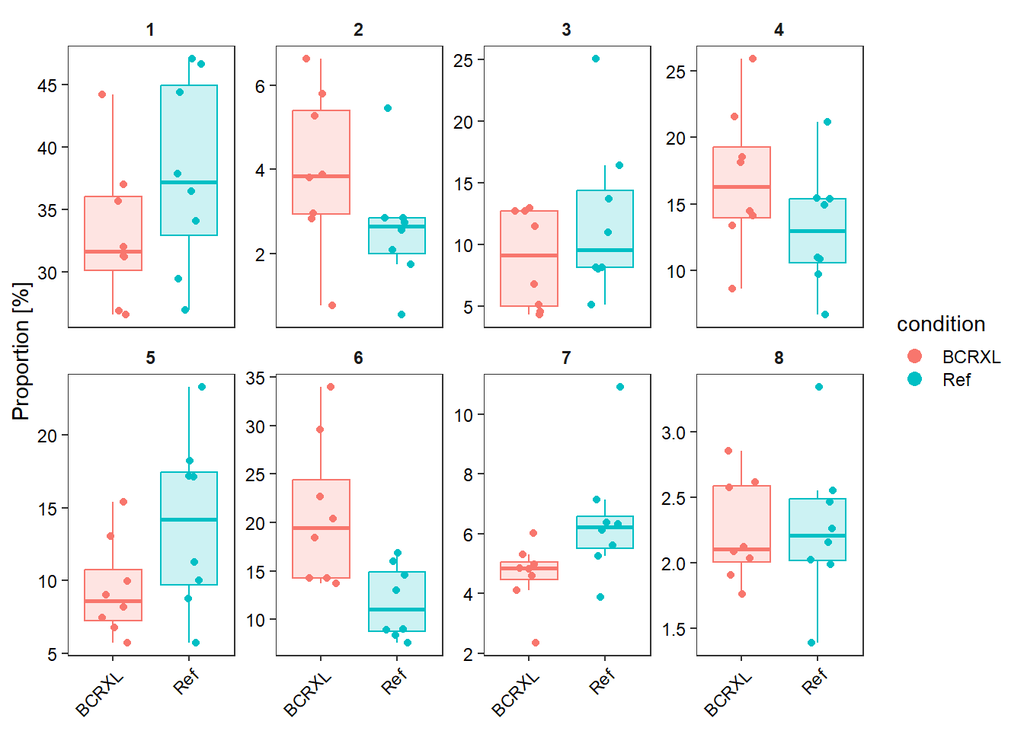

```r
plotAbundances(sce, k = "meta8", by = "cluster_id")
```

## Question 5

*Dimension reduction*

1. Using runDR(), compute a UMAP embedding of at most 500 cells per sample.

```r
sce <- runDR(sce, dr = "UMAP", cells = 500, features = "type", assay = "exprs")
```

2. Using plotDR(), plot UMAP embeddings colored by patient_id and condition.

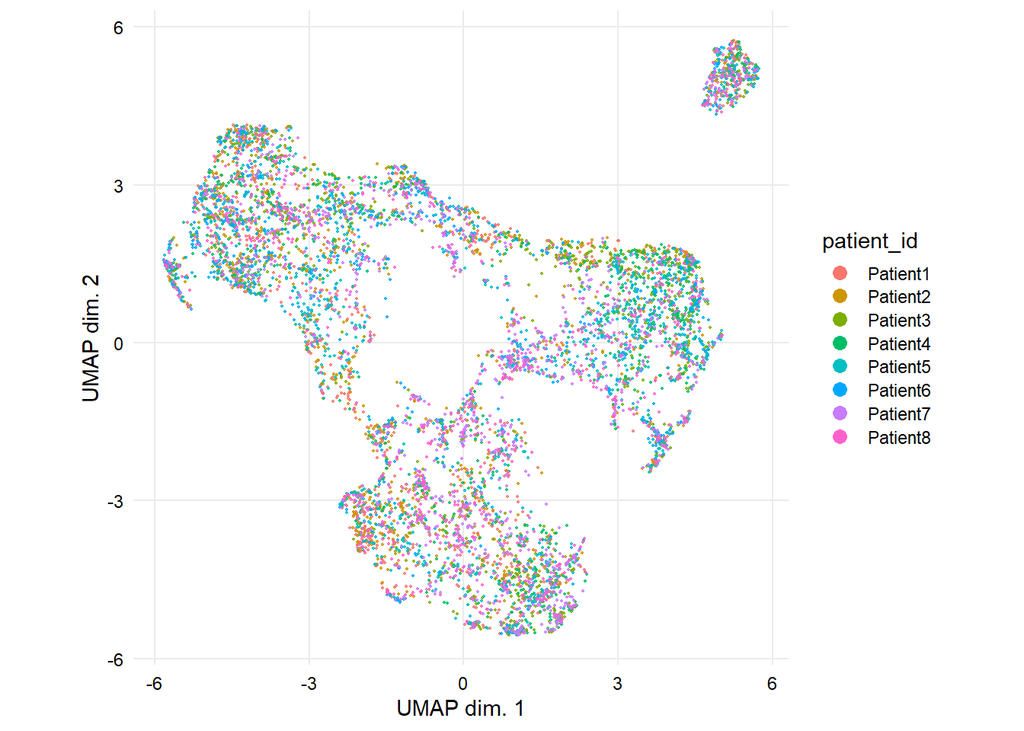

```r
plotDR(sce, color_by = "patient_id")
```

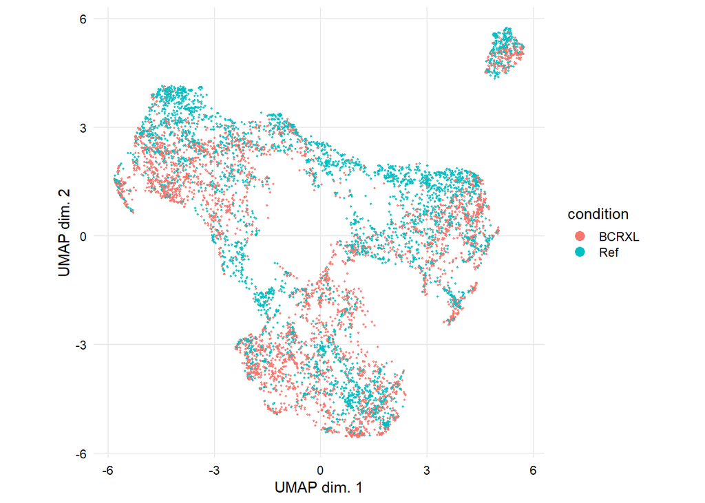

```r
plotDR(sce, color_by = "condition")
```

3. Is there any apparent patient effect? How does BCRXL stimulation manifest itself?

## Question 6

*Exploratory data analysis*

1. Generate MDS plots with samples colored by patient_id and condition.

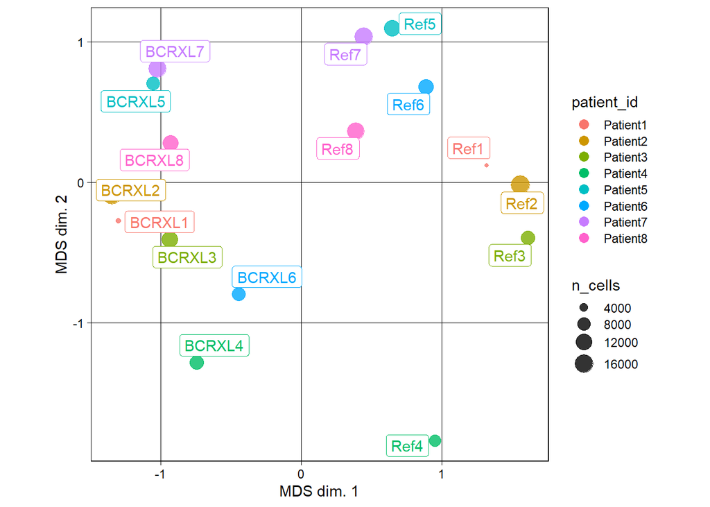

```r
pbMDS(sce, by = "sample_id", k = "meta8", fun = "mean",
      color_by = "patient_id")
```

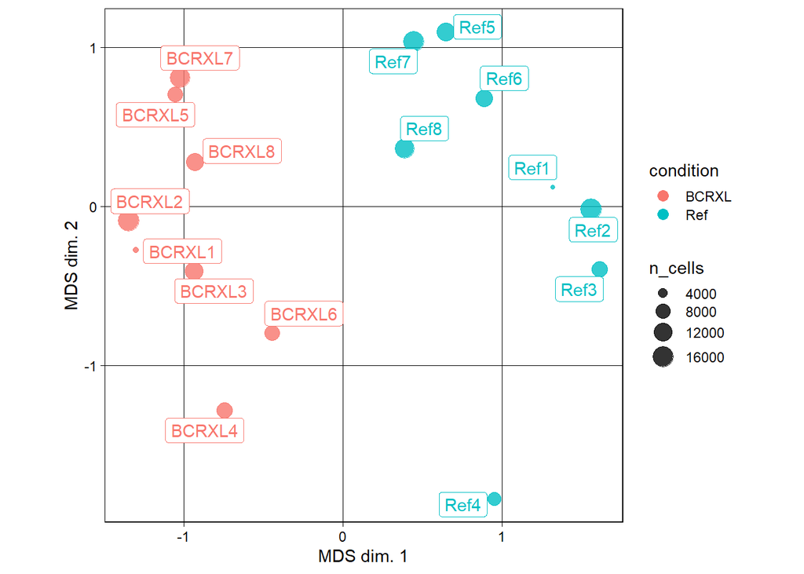

```r
pbMDS(sce, by = "sample_id", k = "meta8", fun = "mean",
      color_by = "condition")
```

2. Comment on how samples group together or are separated from one another.

The datapoints in the MDS plot colored according to patientID seem to be approximately equally distributed. In the second MDS plot, we can clearly see how the first dimension separates the two conditions (BCRXL and Ref).

## Question 7

*Differential state (DS) analysis*

0. Load the diffcyt package.
1. Fit a LMM to test for DS with and without accounting for patient effects, and using the 8-metacluster level of clustering.

```r
ei <- metadata(sce)$experiment_info

# create model formulas with & without patient effect
ds_formula1 <- createFormula(ei, cols_fixed = c("condition", "patient_id"))
ds_formula2 <- createFormula(ei, cols_fixed = "condition")

# create contrast matrix
contrast1 <- createContrast(c(0, 1, rep(0, 7)))
contrast2 <- createContrast(c(0, 1))

# run 'diffcyt' 2x
res_ds1 <- diffcyt(sce, ei,
    formula = ds_formula1,
    contrast = contrast1,
    analysis_type = "DS",
    method_DS = "diffcyt-DS-LMM",
    clustering_to_use = "meta8")

res_ds2 <- diffcyt(sce, ei,
    formula = ds_formula2,
    contrast = contrast2,
    analysis_type = "DS",
    method_DS = "diffcyt-DS-LMM",
    clustering_to_use = "meta8")

# extract result tables
tbl_ds1 <- rowData(res_ds1$res)
tbl_ds2 <- rowData(res_ds2$res)
```

2. Print a table of the number of DS findings for each model at an FDR cutoff of 5%.

```r
# number of DS findings without accounting for patient effects
tbl_ds2[tbl_ds2$p_adj < 0.05,]
```

```
DataFrame with 42 rows and 4 columns
    cluster_id marker_id       p_val       p_adj
      <factor>  <factor>   <numeric>   <numeric>
1            1     pNFkB 1.44285e-04 0.000850520
2            2     pNFkB 9.50763e-04 0.003600878
3            3     pNFkB 2.05407e-04 0.001023640
4            4     pNFkB 1.23368e-05 0.000151000
5            5     pNFkB 3.75724e-05 0.000350676
...        ...       ...         ...         ...
4            4       pS6 1.20918e-03 4.23214e-03
5            5       pS6 1.07569e-02 3.34660e-02
6            6       pS6 5.75568e-04 2.47937e-03
7            7       pS6 3.68328e-12 4.12527e-10
8            8       pS6 1.00081e-02 3.20259e-02
```

```r
# number of DS findings accounting for patient effects
tbl_ds1[tbl_ds1$p_adj < 0.05,]
```

```
DataFrame with 58 rows and 4 columns
    cluster_id marker_id       p_val       p_adj
      <factor>  <factor>   <numeric>   <numeric>
1            1     pNFkB 1.91920e-03 0.006513660
2            2     pNFkB 5.58326e-04 0.002756284
3            3     pNFkB 7.53352e-05 0.000703129
4            4     pNFkB 7.62969e-04 0.003560524
5            5     pNFkB 4.88080e-04 0.002695356
...        ...       ...         ...         ...
4            4       pS6 5.25915e-03 1.47256e-02
5            5       pS6 2.00179e-02 4.23020e-02
6            6       pS6 1.69889e-03 5.94612e-03
7            7       pS6 3.43062e-08 3.84229e-06
8            8       pS6 1.82290e-02 3.92624e-02
```

3. How many tests are there in total and why?

```r
dim(topTable(res_ds2, top_n = Inf))[1]
```

```
[1] 112
```

We perform a test for every cluster-marker combination. Since there are 14 cell state markers and 8 metaclusters: 14*8 = 112 possible combinations.

4. Comment on what effect accounting for patient variability has on sensitivity.

```r
print(table(tbl_ds2$p_adj <= 0.05))
```

```
FALSE  TRUE
   70    42
```

```r
print(table(tbl_ds1$p_adj <= 0.05))
```

```
FALSE  TRUE
   54    58
```

We can assume that accountiing for patient effects enhances the sensivity, which is defined as TP/(TP+FN), because the number of TP (the detected markers) increases from 42 to 58.

## Question 8

*Visualizing DS results*

1. Visualize the top 50 hits using plotDiffHeatmap.

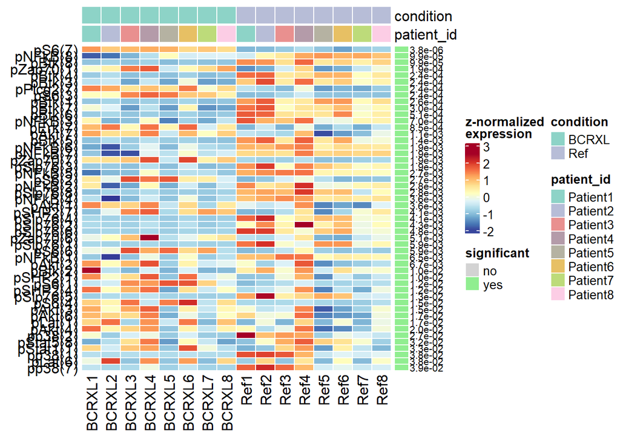

```r
plotDiffHeatmap(sce, tbl_ds1, top_n = 50, all = TRUE, fdr = 0.05)
```

2. Plot UMAPs colored by their expression and split by condition.

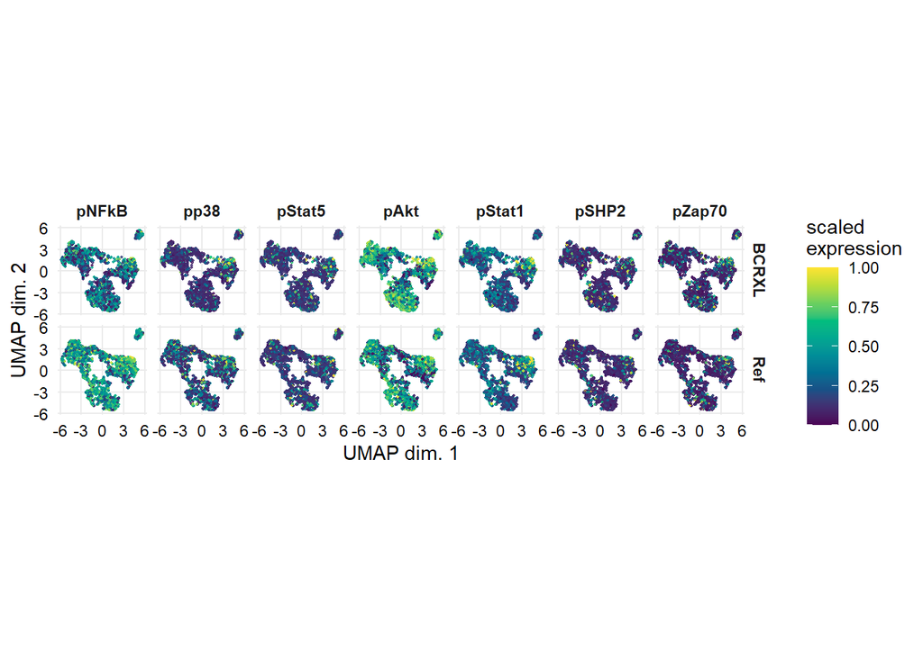

```r
plotDR(sce, facet_by = "condition", color_by = c(state_markers(sce)[1:7]))
```

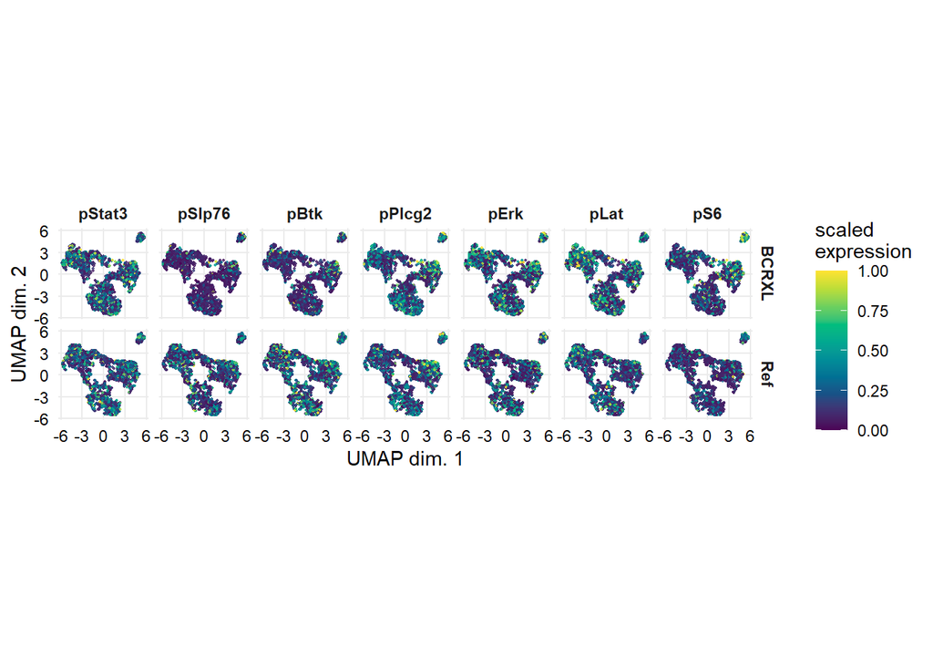

```r
plotDR(sce, facet_by = "condition", color_by = c(state_markers(sce)[8:14]))
```